# Amazon’s Dynamic Pricing Engine

The Math Behind 2.5 Million Daily Price Changes

Vigneshwaran Siva Sankaran

2026-06-01

**29**

price changes per **second**

2.5 million per day · across 350 million products

> *“Amazon’s algorithm does in milliseconds what a pricing team does in weeks.”*

## The Problem with Static Pricing

**You sell a Bluetooth speaker at $49.**

Then:

- 🏪 Competitor drops to **$39**
- 🎄 Holiday season — demand **spikes**
- 📦 5,000 units need to move in **30 days**

**One price can’t answer all three questions.**

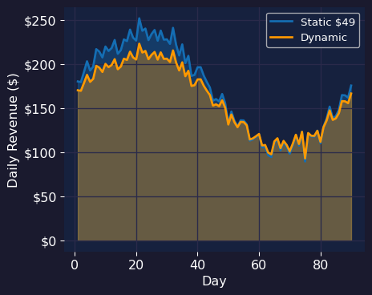

## Price Elasticity — The Core Idea

The single number that makes dynamic pricing possible:

$$\varepsilon = \frac{\% \Delta Q}{\% \Delta P}$$

| $\|\varepsilon\|$ | Label | Meaning | Example |
| --- | --- | --- | --- |
| $> 1$ | **Elastic** | Shoppers are price-sensitive | Electronics |
| $= 1$ | Unit elastic | Equal response | — |
| $< 1$ | **Inelastic** | Shoppers pay regardless | Prime membership |

For $|\varepsilon|=1.5$: a **10% price hike** causes a **15% drop in units sold**.

## The Log-Log Demand Model

Amazon estimates elasticity using **regression on log-transformed data**:

$$\ln Q_t = \alpha + \underbrace{\varepsilon}_{\text{elasticity}} \ln P_t + \gamma \mathbf{X}_t + u_t$$

**Why log-log?**

- $\varepsilon$ is elasticity **directly** — no extra math
- Captures: “$1 matters more at $5 than at $500”
- Multiplicative structure matches demand reality

**Controls ($\mathbf{X}_t$):**

- Day of week / holidays
- Competitor prices
- Season / trend
- Promotions

## Simulating Amazon’s Data

**Show simulation code**

```python
np.random.seed(2024)
n = 365
TRUE_E = -1.8
prices = 49 + np.random.uniform(-8,8,n)
comp   = 45 + np.random.uniform(-6,6,n)
dow    = (np.arange(n)%7>=5).astype(float)
season = 0.3*np.sin(2*np.pi*np.arange(n)/365)
log_q  = 7.5 + TRUE_E*np.log(prices) - 0.6*np.log(comp) + 0.15*dow + 0.2*season + np.random.normal(0,0.12,n)
qty    = np.exp(log_q).astype(int)

df = pd.DataFrame({"price":prices.round(2),"comp_price":comp.round(2),
                   "weekend":dow,"quantity":qty,"day":np.arange(n),
                   "log_price":np.log(prices),"log_comp":np.log(comp),
                   "log_qty":np.log(qty+0.5)})

fig, axes = plt.subplots(1,2,figsize=(9,4))
axes[0].scatter(df.price, df.quantity, alpha=0.3, s=15, color=ORANGE)
axes[0].set_xlabel("Price ($)"); axes[0].set_ylabel("Quantity")
axes[0].set_title("Raw: Price vs Quantity", color="white")

axes[1].scatter(df.log_price, df.log_qty, alpha=0.3, s=15, color=TEAL)
m,b = np.polyfit(df.log_price, df.log_qty, 1)
xs = np.linspace(df.log_price.min(), df.log_price.max(), 100)
axes[1].plot(xs, m*xs+b, color=ORANGE, lw=2.5, label=f"slope = {m:.2f}")
axes[1].set_xlabel("log Price"); axes[1].set_ylabel("log Quantity")
axes[1].set_title("Log-Log: Linear Relationship", color="white")
axes[1].legend()
plt.tight_layout(); plt.show()
```

[figure not shown]

## Fitting the Model

```python
model = smf.ols(
    "log_qty ~ log_price + log_comp + weekend + np.sin(2*np.pi*day/365)",
    data=df
).fit()

results = pd.DataFrame({
    "Coefficient": model.params.round(3),
    "Std Error":   model.bse.round(3),
    "p-value":     model.pvalues.round(4),
}).rename(index={
    "Intercept":                     "Intercept (α)",
    "log_price":                     "log Price (ε ← elasticity)",
    "log_comp":                      "log Competitor Price",
    "weekend":                       "Weekend Dummy",
    "np.sin(2 * np.pi * day / 365)": "Seasonal Sine",
})
print(results.to_string())
print(f"\nR² = {model.rsquared:.3f}   |   True elasticity = {TRUE_E}")
```

[output not shown]

## The Causal Trap

**The problem:**

Amazon raises prices before holidays. Holiday demand is also high.

$$P_t \uparrow \;\text{and}\; Q_t \uparrow \;\text{simultaneously}$$

OLS sees **positive correlation** → wrong sign!

This is **simultaneity bias** (endogeneity).

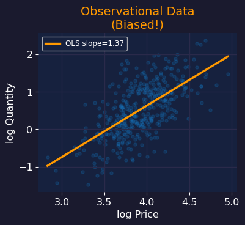

## The Fix: Randomised Price Experiments

**Amazon’s solution:**

Run **A/B tests on prices** — randomly assign different prices to different customer cohorts.

Random assignment $\Rightarrow$ price variation is uncorrelated with demand shocks $\Rightarrow$ **causal estimate**.

$$\hat{\varepsilon}_{causal} = \frac{\text{Cov}(\ln Q, Z)}{\text{Cov}(\ln P, Z)}$$

where $Z$ = treatment assignment (fully random).

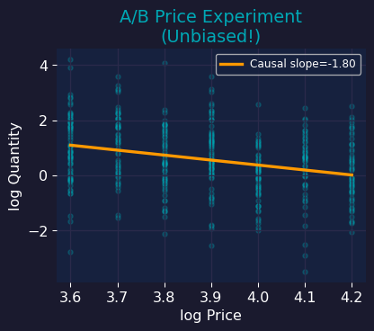

## From Elasticity to Optimal Price

Once we know elasticity, the optimal price has a **closed-form solution**:

$$\boxed{P^* = \frac{|\varepsilon|}{|\varepsilon| - 1} \times c}$$

For our speaker: $|\varepsilon| = 1.8$, $c = \$15$:

$$P^* = \frac{1.8}{0.8} \times \$15 = \$33.75$$

**Show profit maximisation code**

```python
mc = 15; e = -1.8; P0 = 49; Q0 = 1000
def qty(p): return Q0*(p/P0)**e
def profit(p): return (p-mc)*qty(p)

pg = np.linspace(20,80,300)
pf = [profit(p) for p in pg]
oi = np.argmax(pf)

fig,axes = plt.subplots(1,2,figsize=(9,3.5))

axes[0].plot(pg,[qty(p) for p in pg],color=TEAL,lw=2.5)
axes[0].axvline(49,color=BLUE,lw=1.8,linestyle="--",label="Current $49")
axes[0].axvline(pg[oi],color=ORANGE,lw=1.8,linestyle="--",label=f"Optimal ${pg[oi]:.0f}")
axes[0].set_xlabel("Price ($)"); axes[0].set_ylabel("Units/day")
axes[0].set_title("Demand Curve",color="white"); axes[0].legend(fontsize=9)

axes[1].plot(pg,pf,color=ORANGE,lw=2.5)
axes[1].axvline(49,color=BLUE,lw=1.8,linestyle="--",label=f"Current: ${profit(49):,.0f}/day")
axes[1].axvline(pg[oi],color=ORANGE,lw=1.8,linestyle="--",label=f"Optimal: ${pf[oi]:,.0f}/day")
axes[1].set_xlabel("Price ($)"); axes[1].set_ylabel("Daily Profit ($)")
axes[1].set_title("Profit Landscape",color="white"); axes[1].legend(fontsize=9)
axes[1].yaxis.set_major_formatter(mticker.FuncFormatter(lambda x,_:f"${x:,.0f}"))

plt.tight_layout(); plt.show()
```

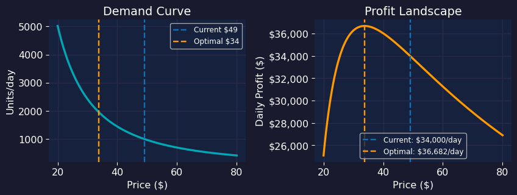

## A Worked Example: The $3 Decision

```python
mc, elasticity, P0, Q0 = 15, -1.8, 49, 1000

def quantity(p): return Q0*(p/P0)**elasticity
def profit(p):   return (p-mc)*quantity(p)

for new_p in [46, 44, 34]:
    dQ = quantity(new_p) - quantity(P0)
    dP = profit(new_p)   - profit(P0)
    flag = "✅ Cut" if dP > 0 else "❌ Hold"
    print(f"${P0}→${new_p}: ΔQty={dQ:+.0f}  ΔProfit={dP:+,.0f}  → {flag}")
```

```
$49→$46: ΔQty=+120  ΔProfit=+734  → ✅ Cut
$49→$44: ΔQty=+214  ΔProfit=+1,199  → ✅ Cut
$49→$34: ΔQty=+931  ΔProfit=+2,681  → ✅ Cut
```

Cutting to **$34** (near the model’s optimal) captures the most profit — but the algorithm recalculates this **every few seconds** as elasticity, inventory, and competitor prices shift.

## What Else Feeds the Engine?

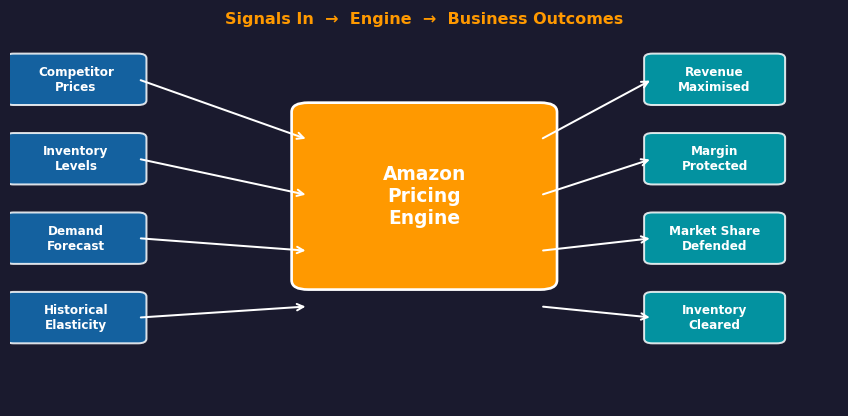

## Ethics: Is Dynamic Pricing Fair?

**Concerns** ⚠️

- **Price discrimination** — different customers, different prices for the same product
- **Surge exploitation** — essentials rise in emergencies automatically
- **Trust erosion** — gaming behavior (abandon cart to trigger price drop)
- Congressional scrutiny on Amazon during COVID-19

**Best Practice** ✅

- Show **price history** (Amazon now does this)
- Hard **price floors** on essentials during crises
- Price consistency within a **single checkout session**
- Transparent pricing **policy disclosure**

The algorithm doesn’t have ethics built in — **marketers do**. The math is neutral; how it’s deployed is not.

## Key Takeaways

1. **Elasticity is the anchor** — estimate how quantity responds to price changes, rigorously.
2. **Log-log regression = direct elasticity** — the coefficient on log price *is* your elasticity.
3. **OLS on observational data is biased** — price and quantity are jointly determined. Use A/B tests.
4. **Optimal price formula:** $P^* = \frac{|\varepsilon|}{|\varepsilon|-1} \times c$ — closed-form once you know elasticity and cost.
5. **Signals stack** — competitor prices, inventory, seasonality, and segment all shift the demand curve continuously.
6. **The math is neutral; deployment isn’t** — pricing algorithms require ethical guardrails.

Dynamic pricing = **demand estimation + causal inference + optimisation**, running at machine speed.

Thank You

**Vigneshwaran Siva Sankaran** Marketing Analytics · UC San Diego Rady School

*“Get the elasticity right, and the optimal price follows automatically.”*

Marketing Analytics · Amazon Dynamic Pricing